# Assignment 7: Constructing Likelihood Ratio Confidence Interval

Sean Schilk

3/24/26

## **Assignment Objectives**

- Reinforce the likelihood concepts and MLE.
- Understand the concepts of confidence intervals.
- Master the process of finding likelihood ratio confidence interval of unknown parameter.

## **Policies of Using AI Tools**

**Policy on AI Tool Use**: You must adhere to the AI tool policy specified in the course syllabus. The direct copying of AI-generated content is strictly prohibited. All submitted work must reflect your own understanding; where external tools are consulted, content must be thoroughly rephrased and synthesized in your own words.

**Code Inclusion Requirement**: Any code included in your essay must be properly commented to explain the purpose and/or expected output of key code lines. Submitting AI-generated code without meaningful, student-added comments will not be accepted.

**One Parameter Lindley Distribution**

The **Lindley distribution** is a **continuous probability distribution** proposed by D.V. Lindley in 1958. It represents a **weighted mixture** of exponential and gamma distributions, providing a flexible single-parameter model for lifetime data.

$$f(x;\theta) = \frac{\theta^2}{1+\theta}(1+x)e^{-\theta x}, \quad x >
0, \quad \theta > 0$$

where $x$ = random variable (e.g., time, size, amount) and $\theta$ = shape parameter controlling the distribution.

Given an independent random sample $X_1, X_2, \dots, X_n$:

$$L(\theta) = \prod_{i=1}^n f(x_i;\theta) = \prod_{i=1}^n \left[
\frac{\theta^2}{1+\theta} (1 + x_i) e^{-\theta x_i} \right].$$

Let $S = \sum_{i=1}^n x_i$, $\bar{x} = S/n$, and $C = \sum_{i=1}^n \ln(1 + x_i)$ (constant with respect to $\theta$):

$$\ell(\theta) = \ln L(\theta) = n \ln\left( \frac{\theta^2}{1+\theta}
\right) + C - \theta S.$$

After some algebra, we obtain the closed form of the MLE of $\theta$ in the following

$$\boxed{\hat{\theta} = \frac{1 - \bar{x} + \sqrt{\bar{x}^2 + 6\bar{x} +
1}}{2\bar{x}}}$$

As good exercise, we can derive the following Fisher information of $\theta$:

$$\boxed{I(\theta) = \frac{2}{\theta^2} - \frac{1}{(1+\theta)^2}}$$

**This assignment focuses on constructing various confidence intervals of the shape parameter $\theta$ in the Lindley distribution.**

## **Question: Customer Service Times (minutes)**

```r
data <- c(3.2, 5.8, 7.1, 4.5, 10.3, 6.2, 8.7, 5.1, 12.5, 6.9,
9.4, 5.7, 11.8, 4.9, 9.1, 6.5, 13.2, 7.8, 10.6, 6.1,
8.9, 5.4, 12.1, 7.3, 9.8, 5.9, 11.4, 6.8, 10.9, 7.5,
4.2, 8.3, 6.4, 14.1, 5.6, 9.7, 7.9, 11.1, 6.7, 10.2,
5.3, 8.6, 7.2, 12.9, 6.3, 9.3, 8.1, 13.7, 7.6, 10.8)
```

Assuming the data follow a one-parameter Lindley distribution, construct a $95\%$ confidence interval for the parameter $\theta$ using the provided data and the specified methods. For each of the following questions, first describe your reasoning process for the analysis, then write code to perform the actual analysis. Finally, summarize the results to conclude the question.

1. Construct a **95% asymptotic confidence interval** based on the asymptotic sampling distribution of the maximum likelihood estimator (MLE) of $\theta$.

Given the closed form of the MLE, I was able to compute $\hat{\theta}$ from the dataset. Then using the fisher information provided, I was then able to find the asymptotic variance and then I standardized. As the MLE follows an asymptotic normal distribution, I used $\hat{\theta}$ and the standard error to construct the 95% CI.

```r
xbar <- mean(data) # sample mean
n <- length(data)# sample size

# given theta_hat equation
theta_hat <- (1 - xbar + sqrt(xbar^2 + 6*xbar + 1)) / (2 * xbar)


# given Fisher information
FisherTheta <- 2/ theta_hat^2 - 1 / (1 + theta_hat)^2

# Standard errors
standardtheta <- 1/sqrt(n*FisherTheta)

# CI
ci.low <- theta_hat - qnorm(1 - 0.025) * standardtheta
ci.up <-  theta_hat - qnorm(0.025) * standardtheta
ci <- c(ci.low, ci.up)

cat("wald 95% CI for theta:\n",
    "Asymptotic CI: [", ci, "] \n")
```

```
wald 95% CI for theta:
 Asymptotic CI: [ 0.1758057 0.2623931 ]
```

We are 95% confident that the true value of $\theta$ lies between 0.176 and 0.262

2. Construct a **95% likelihood ratio confidence interval** for $\theta$.

The first step to constructing the LR confidence interval here was to use the MLE, which was $\hat{\theta}$ from the previous question, to compute the max, which, after given the likelihood function, we can just plug in $\hat{\theta}$ to find. Then, we have to solve for the 2 points to find the 2-sided CI. We will set the second function equal to 0 to solve, to be able to use the uniroot() function.

```r
S <- sum(data)
n <- length(data)
xbar <- S / n
C <- sum(log(1+data))

# Given log likelihood function
fun <-  function(x) {
    n * log(x^2 / (1 + x)) + C - x * S
}
lmax <- fun(theta_hat) #max

# set up so able to solve for 2 pounts
fun2 <- function(x) {
  fun(x) - lmax + 3.841459/2
}
fun2(theta_hat)
```

```
[1] 1.920729
```

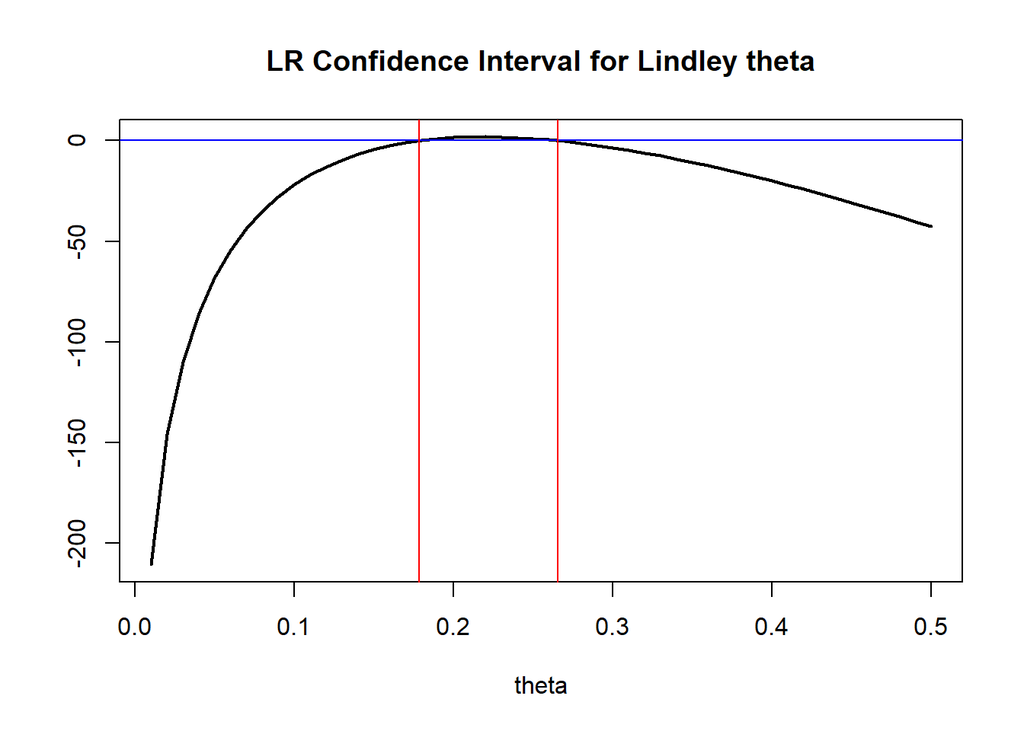

```r
xx <- seq(0.01, .5, length = n)
plot(xx, fun2(xx), type = "l", lwd = 2,
     main = "LR Confidence Interval for Lindley theta",
     xlab = "theta",
     ylab = "")
abline(h = 0, col = "blue")
theta_L <- uniroot(fun2, interval = c(0.01, theta_hat))$root
theta_U <- uniroot(fun2, interval = c(theta_hat, 3))$root
abline(v = c(theta_L, theta_U), col = "red")
```

```r
cat("theta_L: ",theta_L,"theta_U: ", theta_U)
```

```
theta_L:  0.1786338 theta_U:  0.2653483
```

We are 95% confident that the true value of $\theta$ lies between 0.179 and 0.265

3. Assuming the two confidence intervals above are valid, compare them in terms of performance and make a recommendation. Justify your recommendation.